# Advanced Topics: Practical

jonashaslbeck@gmail.com

# 1 Mixed Graphical Models (MGMs)

## 1.1 Exploring the data

We use data from an extensive ESM study from a single individual diagnosed with major depression. The data set consists of 51 variables measured on 1476 time points on 238 consecutive days (Wicherts et al., 2016). The variables include questions regarding mood, self-esteem, social interaction, physical activity, events and symptoms of depression.

The measurements were recorded after notifications on the individual’s smart phone, which were presented at 10 time points each day whose intervals were pseudo-randomized with average length of 90 min between 7am30 and 10pm30. During the measured time interval, a double-blind medication dose reduction was carried out, consisting of a baseline period, the dose reduction, and two post assessment periods. For a detailed description of this data set see Kossakowski et al., (2017).

The data along with a detailed description can be found in Kossakowski et al. (2017), but it is also automatically loaded with the *mgm* package:

```r
library(mgm) # version 1.2-14

head(symptom_data$data)[, 1:6] # First 6 rows of first 6 variables
```

```
##   mood_relaxed mood_down mood_irritat mood_satisfi mood_lonely mood_anxious
## 1            5        -1            1            5          -1           -1
## 2            4         0            3            3           0            0
## 3            4         0            2            3           0            0
## 4            4         0            1            4           0            0
## 5            4         0            2            4           0            0
## 6            5         0            1            4           0            0
```

```r
head(symptom_data$data_time) # Time information
```

```
##       date dayno beepno beeptime resptime_s resptime_e   time_norm
## 1 13/08/12   226      1    08:58   08:58:56   09:00:15 0.000000000
## 2 14/08/12   227      5    14:32   14:32:09   14:33:25 0.005164874
## 3 14/08/12   227      6    16:17   16:17:13   16:23:16 0.005470574
## 4 14/08/12   227      8    18:04   18:04:10   18:06:29 0.005782097
## 5 14/08/12   227      9    20:57   20:58:23   21:00:18 0.006285774
## 6 14/08/12   227     10    21:54   21:54:15   21:56:05 0.006451726
```

The dataset is contained in the list object `symptom_data`; `symptom_data$data` contains the measurements and `symptom_data$data_time` contains information about when the measurements were taken. The additional list entries contain the variable names, the type of each variable, the number of levels (or categories) of each variable, and a group label for each variable.

In order to keep the practical short, we only consider 14 of the 51 variables. Specifically, we take the subset of all 12 mood-related variables and the two categorical variables *Action* and *Who with*. *Action* indicates the activity the individual was performing since the last notification. And *Who with* indicates the with whom the individual spent time together since the last notification.

```r
symptom_data_short <- symptom_data
selection_ind <- c(which(symptom_data$groups == "Mood"),
                   which(symptom_data$colnames %in% c("Action", "Who with")))

# Subset:
symptom_data_short$data <- symptom_data_short$data[,selection_ind]
symptom_data_short$type <- symptom_data_short$type[selection_ind]
symptom_data_short$level <- symptom_data_short$level[selection_ind]
symptom_data_short$colnames <- symptom_data_short$colnames[selection_ind]
symptom_data_short$groups <- symptom_data_short$groups[selection_ind]
```

## 1.2 Question 1: Estimate MGM

Use the function `mgm()` of the *mgm* package to fit a MGM to the data. You can find the type and the levels of the variables in the datalist (`symptom_data_short$type` and `symptom_data_short$type`). Specify `lambdaSel = "CV"` and `lambdaFolds = 10` to select the regularization parameter with 10-fold cross-validation. Make use of the helpfile `?mgm` and the [mgm paper](https://arxiv.org/abs/1510.06871) (Haslbeck & Waldorp, 2019), if necessary.

Solution:

```r
set.seed(1)

mgm_obj <- mgm(data = as.matrix(symptom_data_short$data),
               type = symptom_data_short$type,
               level = symptom_data_short$level,
               lambdaSel = "CV",
               lambdaFolds = 10,
               pbar = FALSE)
```

```
## Note that the sign of parameter estimates is stored separately; see ?mgm
```

## 1.3 Question 2: Visualize MGM

Visualize the MGM parameters using the *qgraph* package. Make sure to provide the edge colors (which indicate the sign of the relationship) separately via the `qgraph()` argument `edge.color`. You can find them in the *mgm* output object. You can find labels for the variables in `symptom_data_short$colnames`.

Solution:

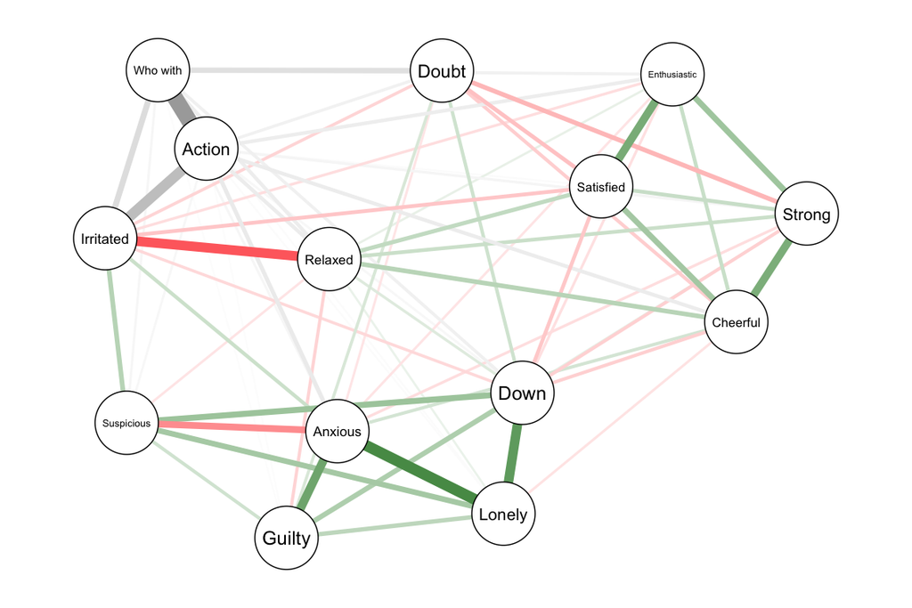

```r
library(qgraph)

Q <- qgraph(mgm_obj$pairwise$wadj,
            layout = "spring",
            edge.color = mgm_obj$pairwise$edgecolor,
            labels = symptom_data_short$colnames)
```

## 1.4 Question 3: Interpreting interactions between continuous variables

Interpret the relationship between the variables *Lonely* and *Down* (only the sign, ignore the exact value). You can request the exact value of the linear relationship with the function `showInteraction()`.

Solution:

```r
showInteraction(mgm_obj, int = c(5,2))
```

```
## Interaction: 2-5
## Weight:  0.3961758
## Sign:  1  (Positive)
```

There is a positive linear relationship between *Lonely* and *Down*. Specifically, when keeping everything else constant, then increasing Lonely (Down) by 1 unit, Down (Lonely) increases by 0.396 units. That is, the interpretation of the interaction parameter is the same as in a multiple linear regression.

## 1.5 Question 4: Interpreting interactions involving categorical variables

Interpret the relationship between the variables *Action* and *Irritated*. This is an interaction between a categorical (*Action*) and a continuous variable (*Irritated*). You can inspect the exact (unaggregated) parameters of this interaction in the output object of the function `showInteraction()`.

Solution:

Since the variable *Action* is categorical with 8 categories, the interaction between *Action* and *Irritated* has more than one parameters. The present edge between the two variables tells us that there is *some* interaction between the two variables. To inspect the exact nature of this interaction, we have to look at all parameters in this interaction. We obtain those parameters using the `showInteraction()` function:

```r
SI <- showInteraction(mgm_obj, int = c(14, 3))
SI
```

```
## Interaction: 3-14
## Weight:  0.4395926
## Sign:  NA  (Not defined)
```

```r
SI$parameters
```

```
## $Predict_3
##   14.0     14.10     14.21     14.27    14.43     14.45     14.60     14.88
## 3   NA 0.8519102 0.7766287 0.5640219 0.451958 0.4635514 0.5246802 0.2708367
##
## $Predict_14
##                3
## 14.0  -0.8504482
## 14.10  0.7147690
## 14.21  0.6611261
## 14.27  0.2027291
## 14.43  0.0000000
## 14.45  0.0000000
## 14.60  0.0000000
## 14.88 -0.1431664
```

First we look up the category labels of *Action* in Kossakowski et al. (2017): 0 = nothing, 10 = work/studies, 21 = caring for others, 27 = taking care of oneself, 43 = active relaxation, 45 = passive relaxation, 60 = eating/drinking, 88 = traveling. Now, we can interpret the interaction from two perspectives: when predicting *Action*, or when predicting *Irritated*. Here we choose to interpret the parameters of the regression on *Action*.

Negative values indicate that increasing *Irritated* leads to a lower probability of observing the respective category of *Action*. That is, feeling irritated leads to a lower probability of doing nothing. In contrast, feeling irritated leads to a higher probability of working, caring for oneself or others. Of course, by “leads to” we mean the typical regression interpretation of parameters, and do not imply a causal direction. Indeed, in this example, the other causal direction is possibly more plausible (i.e., when an individual is working, they get more irritated).

For a more detailed discussion on how to interpret interactions between categorical and other variable see [this blogpost](https://jmbh.github.io/Interactions-between-categorical-Variables-in-mixed-graphical-models).

## 1.6 Question 5: Assess Stability of Estimates

Assess the stability of the edge-weights using the function `resample()`. Set `nB = 5` to minimize computation time in the practical (in practice `nB` should be somewhere between 100-1000). The runtime should be about 1 minute.

Then plot summaries of the bootstrapped sampling distributions with `plotRes()`. Choose `quantiles = c(.05, .95)`.

Solution:

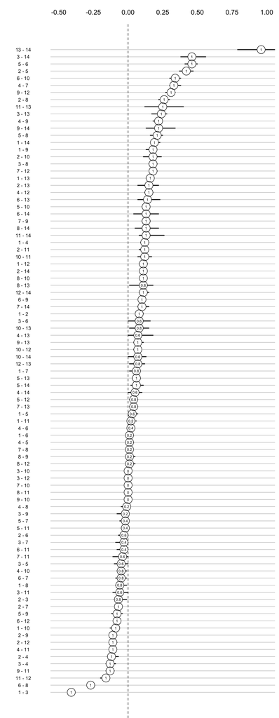

```r
library(qgraph)

# Resampling
res_out <- resample(object = mgm_obj,
                    data = as.matrix(symptom_data_short$data),
                    nB = 5,
                    pbar=FALSE)

# Plotting Summaries
plotRes(object = res_out, quantiles = c(.05, .95))
```

# 2 Nodewise Predictability

## 2.1 Question 6: Compute Nodewise Predictability / Prediction Error

Use the predict function `predict.mgm()` to compute the nodewise predictability for the MGM we fitted above. To do this you need to provide both the model object and the data to `predict.mgm()`. For details see `?predict.mgm`. Which of the *continuous* variables has the highest proportion of explained variance $R^2$?

Solution:

```r
pred_obj <- predict(object = mgm_obj,
                    data = symptom_data_short$data)

pred_obj$errors
```

```
##        Variable  RMSE    R2    CC   nCC CCmarg
## 1  mood_relaxed 0.626 0.608    NA    NA     NA
## 2     mood_down 0.536 0.713    NA    NA     NA
## 3  mood_irritat 0.687 0.527    NA    NA     NA
## 4  mood_satisfi 0.524 0.725    NA    NA     NA
## 5   mood_lonely 0.543 0.705    NA    NA     NA
## 6  mood_anxious 0.671 0.549    NA    NA     NA
## 7   mood_enthus 0.569 0.676    NA    NA     NA
## 8   mood_suspic 0.775 0.399    NA    NA     NA
## 9   mood_cheerf 0.541 0.707    NA    NA     NA
## 10  mood_guilty 0.649 0.578    NA    NA     NA
## 11   mood_doubt 0.747 0.442    NA    NA     NA
## 12  mood_strong 0.570 0.675    NA    NA     NA
## 13     soc_who1    NA    NA 0.703 0.315  0.566
## 14    act_what1    NA    NA 0.487 0.288  0.279
```

The variable *Satisfied* has the highest R2 value (0.725).

We could also visualize nodewise predictability in the network visualization. For reproducible code on how to do this see [this blogpost](http://jmbh.github.io/Predictability-in-network-models/) or the paper Haslbeck & Waldrop (2018).

# 3 Moderated Network Models (MNMs)

This exercise is adapted from [this blog post](https://jmbh.github.io/Moderated-Network-Models-for-continuous-data/) which contains a more detailed analysis of the same data.

## 3.1 Exploring the data

We use a cross-sectional data set with $n=3896$ observations including the variables *hostile*, *lonely*, *nervous*, *sleepy* and *depressed*, which we took from the 92-item Motivational State Questionnaire (MSQ) data set. Each item is answered on a Likert scale with responses 0 (Not at all), 1 (A little), 2 (Moderately), and 3 (Very much).

```r
data <- read.table("https://jmbh.github.io/files/data/msq.csv", sep=",", header=TRUE)
data <- data[, c("hostile", "lonely", "nervous", "sleepy", "depressed")] # subset
data <- na.omit(data) # exclude rows with missing values

head(data)
```

```
##   hostile lonely nervous sleepy depressed
## 1       0      1       1      1         0
## 2       0      0       0      1         0
## 3       0      0       0      0         0
## 4       0      1       2      1         1
## 5       0      0       0      1         0
## 6       0      0       0      2         1
```

## 3.2 Question 7: Estimate MNM with moderator *depressed*

Use the `moderators` argument in the `mgm()` function to estimate a MNM with the only moderator *depressed*. Then inspect the estimated pairwise and moderation effects in `mgm_mod$interactions$indicator` in the output object `mgm_mod`. How many pairwise interactions and how many moderation effects (i.e., 3-way interactions) were estimated?

Solution:

We specify `moderators = 5` because *depressed* is in the fifth column of the data matrix.

```r
# Estimate MNM
set.seed(1)
mgm_mod <- mgm(data = as.matrix(data),
               type = rep("g", 5),
               level = rep(1, 5),
               lambdaSel = "CV",
               ruleReg = "AND",
               moderators = 5,
               threshold = "none",
               pbar = FALSE)
```

```
## Note that the sign of parameter estimates is stored separately; see ?mgm
```

```r
# Which interactions were estimated?
mgm_mod$interactions$indicator
```

```
## [[1]]
##       [,1] [,2]
##  [1,]    1    2
##  [2,]    1    3
##  [3,]    1    4
##  [4,]    1    5
##  [5,]    2    3
##  [6,]    2    4
##  [7,]    2    5
##  [8,]    3    4
##  [9,]    3    5
## [10,]    4    5
##
## [[2]]
##      [,1] [,2] [,3]
## [1,]    1    2    5
## [2,]    1    3    5
## [3,]    2    4    5
## [4,]    3    4    5
```

There are ten nonzero pairwise interactions, and four nonzero moderation effects.

## 3.3 Question 8: Interpreting Pairwise Interaction

Retrieve and interpret the pairwise interaction between *hostile* and *nervous* using the function `showInteraction()` similarly as in Questions 3 and 4.

Solution:

```r
showInteraction(object = mgm_mod, int = c(1,3))
```

```
## Interaction: 1-3
## Weight:  0.1145438
## Sign:  1  (Positive)
```

If the pairwise interaction between *hostile* and *nervous* was not moderated by *depressed* we could apply the usual linear regression interpretation: when increasing Nervous (Hostile) by 1 unit, Hostile (Nervous) increases by $\approx 0.114$, when keeping everything else constant. However, we saw that in `mgm_mod$interactions$indicator` that this pairwise interaction is moderated by *depressed*. This means that the pairwise interaction between *hostile* and *nervous* is only equal to $\approx 0.114$ if the moderator variable is equal to zero (see also next question).

## 3.4 Question 9: Interpreting Moderation Effect

Retrieve the moderation effect of *depressed* on the pairwise interaction between *hostile* and *nervous* using the function `showInteraction()` similarly as in Questions 3 and 4. Tip: Think of the moderation effect as a three-way interaction. Then, interpret the 3-way interaction as a moderation effect of *depressed*.

Solution:

```r
showInteraction(object = mgm_mod, int = c(1,3,5))
```

```
## Interaction: 1-3-5
## Weight:  0.05279001
## Sign:  1  (Positive)
```

Why does the pairwise effect represent exactly the effect when Depression is equal to zero? The reason is that we mean-centered all variables before estimation by default. This leads to the situation that the pairwise interaction parameter represents the moderated effect when conditioning on the moderator value with the highest density (assuming that the moderator variable is symmetric and unimodal, which we do here because we assume all variables to be conditional Gaussian distributions). Un-centered variables often lead to pairwise parameters that are conditioned on moderator values that do not exist in the data, which leads to pairwise parameters that have no meaningful interpretation. For a detailed discussion of this [see here](https://jmbh.github.io/CenteringPredictors/).

## 3.5 Question 10: Visualize with Factor Graph

Visualize the MNM estimated in Question 7 with a Factor Graph using the function `FactorGraph()`.

Solution:

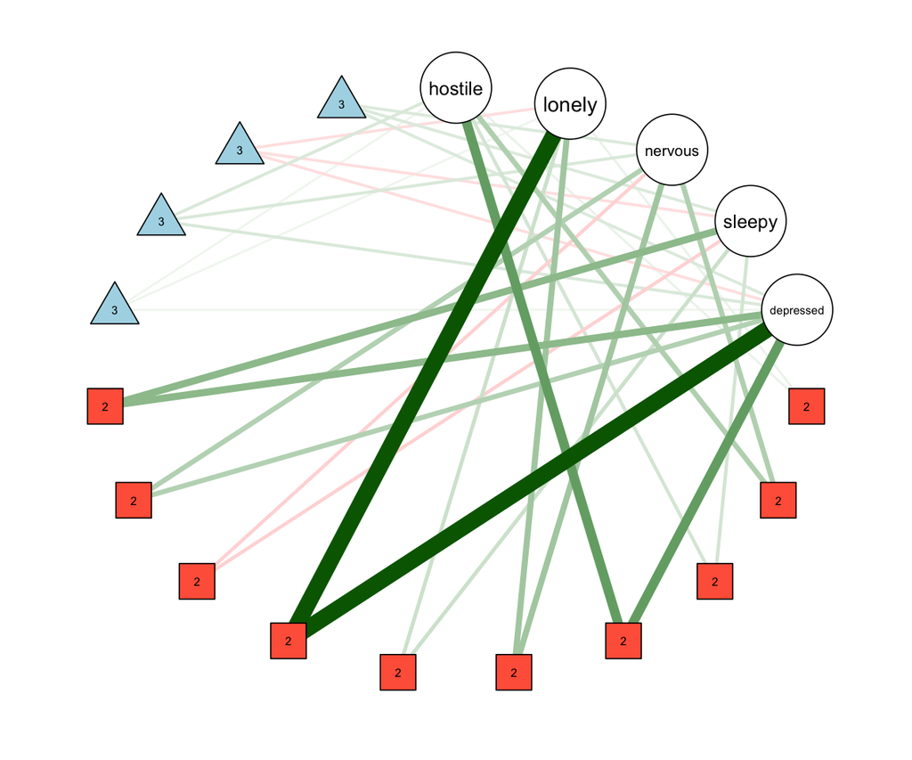

```r
FactorGraph(object = mgm_mod, labels = colnames(data))
```

The circle nodes are variables, the square nodes are pairwise interactions, and the triangle nodes are three-way interactions / moderation effects. For a more detailed discussion see [this blog post](https://jmbh.github.io/Moderated-Network-Models-for-continuous-data/) or [this paper](https://www.tandfonline.com/doi/full/10.1080/00273171.2019.1677207)

## 3.6 Question 11: Conditioning on the Moderator & Plotting

An alternative way to analyze and visualize a moderated network model is to condition on the moderators and plot the resulting pairwise network(s). For the above model, use the function `condition()` to condition the MNM on the values *depressed* = 0, *depressed* = 1, and *depressed* = 2. Then visualize the resulting pairwise models next to each other, similarly as in Question 2. Make sure to use the same layout in all plots, and keep the `maximum` argument in `qgraph()` constant, to ensure that the visualizations are comparable.

Solution:

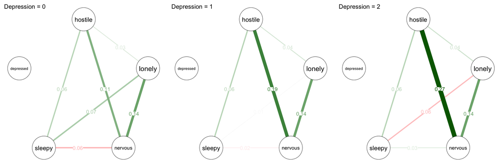

```r
# Condition
cond0 <- condition(object = mgm_mod,
                   values = list('5' = 0))

cond1 <- condition(object = mgm_mod,
                   values = list('5' = 1))

cond2 <- condition(object = mgm_mod,
                   values = list('5' = 2))

# Visualize
l_cond <- list(cond0, cond1, cond2)

library(qgraph)
par(mfrow=c(1,3))

max_val <- max(max(l_cond[[1]]$pairwise$wadj),
               max(l_cond[[2]]$pairwise$wadj),
               max(l_cond[[3]]$pairwise$wadj))

for(i in 1:3) qgraph(l_cond[[i]]$pairwise$wadj, layout="circle",
                     edge.color=l_cond[[i]]$pairwise$edgecolor,
                     labels = colnames(msq_p5),
                     maximum = max_val,
                     edge.labels = TRUE, edge.label.cex=2,
                     vsize=20, esize=18,
                     title = paste0("Depression = ", (0:2)[i]))
```

Note that because we included the moderator as a continuous variables, we can only observe linear moderation effects. However, one could also bin the moderator in categories and enter *depressed* as a categorical variable. Then, one can also recover non-linear moderation effects (e.g. the relationship between X-Y is positive for *depressed = 0*, negative for *depressed = 1* and again positive for *depressed = 2*).

## 3.7 Question 12: Assessing Stability

Stability of estimates can be assessed similarly as for pairwise MGMs via resampling. Again, use `resample()` and `PlotRes()` to assess the stability of the estimates (see Question 5). Again, choose `nB = 5` to minimize the computation time in the practical. In practice the number of bootstrap samples should be in the order of 1000s.

Solution:

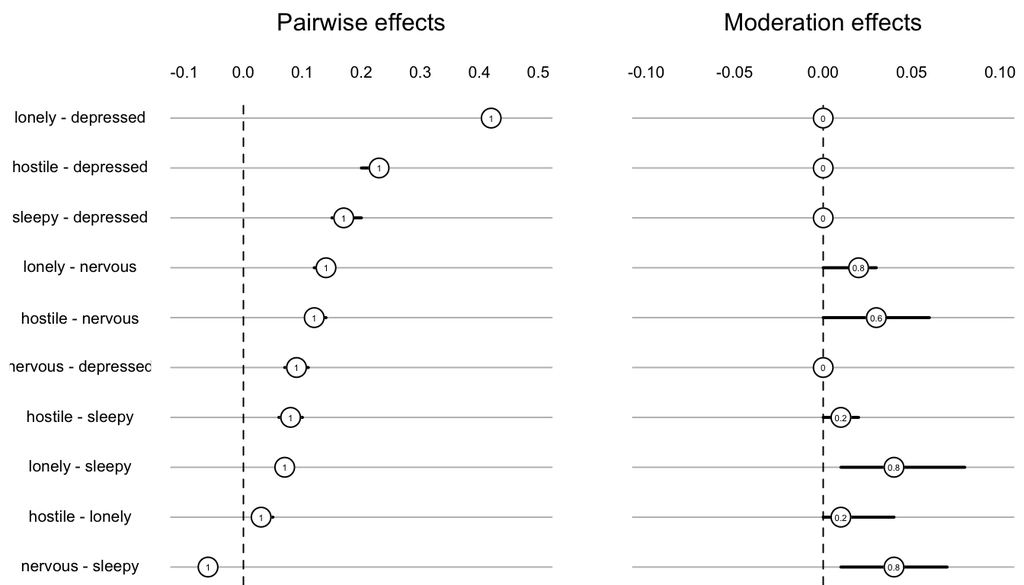

```r
# Resampling
set.seed(1)
res_obj <- resample(object = mgm_mod,
                    data = as.matrix(data),
                    nB = 5,
                    pbar = FALSE)

# Plotting
plotRes(res_obj,
        axis.ticks = c(-.1, 0, .1, .2, .3, .4, .5),
        axis.ticks.mod = c(-.1, -.05, 0, .05, .1),
        cex.label = 1,
        labels = colnames(msq_p5),
        layout.width.labels = .40)
```

Note that this visualization only works for MNMs with a single moderator. However, `resample()` works with any number of moderators, and the bootstrapped sampling distributions of all parameters can be obtained from `res_obj` and summarized as needed.

# 4 Mixed VAR (mVAR) Models

We now return to the data set used in Sections 1 and 2. So far, we estimated MGMs on these data, which capture statistical dependencies between variables *at the same time point*. Now we are interested in dependencies *across time*. Such dependencies across time can be modeled with a mixed Vector Autoregressive (mVAR) model. Specifically, we are interested in how variables are related over a time-interval of 90min, which is in our data set is time between two subsequent measurements.

## 4.1 Question 13: Data used for Estimation

When fitting such (mixed) VAR model with lag = 1, we can only use the measurement at time point $t$ if also the measurement at time point $t-1$ is available. Plot the first 10 rows of the data frame with the time information (`symptom_data_short$data_time`). How many measurements (rows) can we use for estimation? (or equivalently: how many rows do the VAR design matrices have?)

Solution:

```r
symptom_data_short$data_time[1:10, ]
```

```
##        date dayno beepno beeptime resptime_s resptime_e   time_norm
## 1  13/08/12   226      1    08:58   08:58:56   09:00:15 0.000000000
## 2  14/08/12   227      5    14:32   14:32:09   14:33:25 0.005164874
## 3  14/08/12   227      6    16:17   16:17:13   16:23:16 0.005470574
## 4  14/08/12   227      8    18:04   18:04:10   18:06:29 0.005782097
## 5  14/08/12   227      9    20:57   20:58:23   21:00:18 0.006285774
## 6  14/08/12   227     10    21:54   21:54:15   21:56:05 0.006451726
## 7  15/08/12   228      2    10:03   10:03:13   10:04:49 0.008574157
## 8  15/08/12   228      3    10:43   10:43:24   10:45:09 0.008690614
## 9  15/08/12   228      4    12:44   12:45:09   12:46:32 0.009042897
## 10 15/08/12   228      5    14:09   14:09:46   14:11:32 0.009290368
```

For six rows (3,5,6,8,9,10) measurements at the previous time point are available. Thus, the VAR design matrix has 6 rows.

## 4.2 Question 14: Estimate mVAR Model

Use the function `mvar()` to estimate a mixed VAR model with lag = 1. Similarly as for the MGM above, select the regularization parameters with 10-fold cross-validation. To ensure that only time points are used for estimation for which we have also the previous time point, we provide the number of the notification (the “beep”) via the argument `beepvar` and the day of via the argument `dayvar`. Make use of the help file `?mvar` and the [mgm paper](https://arxiv.org/abs/1510.06871), if necessary.

After estimating the model, paste the model object into the console. How many rows are used to estimate the mVAR model? Why don’t we use all 1476 rows?

Solution:

```r
# Fit mVAR model
set.seed(1)
mvar_obj <- mvar(data = symptom_data_short$data,
                 type = symptom_data_short$type,
                 level = symptom_data_short$level,
                 lambdaSel = "CV",
                 lambdaFolds = 10,
                 lags = 1,
                 beepvar = symptom_data_short$data_time$beepno,
                 dayvar = symptom_data_short$data_time$dayno,
                 pbar = FALSE)
```

```
## Note that the sign of parameter estimates is stored separately; see ?mvar
```

```r
# Execute model object in console
mvar_obj
```

```
## mgm fit-object
##
## Model class:  mixed Vector Autoregressive (mVAR) model
## Lags:  1
## Rows included in VAR design matrix:  876 / 1476 ( 59.35 %)
## Nodes:  14
```

We use 876 rows to estimate the VAR model. This is because only for those 876 rows a measurement is available in the previous time point (see Question 13).

## 4.3 Question 15: Visualize mVAR Model

Visualize the mVAR parameters using the *qgraph* package. Make sure to provide the edge colors (which indicate the sign of the relationship) separately via the *qgraph* argument `edge.color`. You can find them in the `mvar()` output object. You can find labels for the variables in `symptom_data_short$colnames`.

Tip: Make sure to transpose (using `t()`) both the parameter matrix and the matrix of edge colors before providing them to `qgraph()`. The reason is that in `mgm` columns predict (point to) rows, while in `qgraph` rows predict (point to) columns.

Solution:

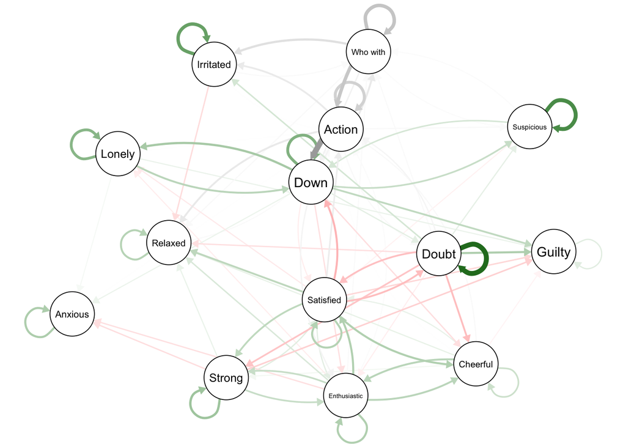

```r
qgraph(t(mvar_obj$wadj[, , 1]),
       layout = "spring",
       edge.color = t(mvar_obj$edgecolor[, , 1]),
       labels = symptom_data_short$colnames)
```

## 4.4 Question 16: Interpret lagged parameters

Interpret the directed edges *doubt* $\rightarrow$ *doubt* and *down* $\rightarrow$ *satisfied*.

Solution:

## 4.5 Question 17: Compare MGM to mVAR

Compare the MGM estimated in the previous section with the mVAR model estimated in this section by plotting them next to each other using `qgraph()`. Make sure that the visualizations are comparable by using the same layout (argument `layout`) and by keeping the scaling of edge-widths constant across the visualizations (argument `maximum`). In which model are the interactions stronger? Do the models show the same structure?

Solution:

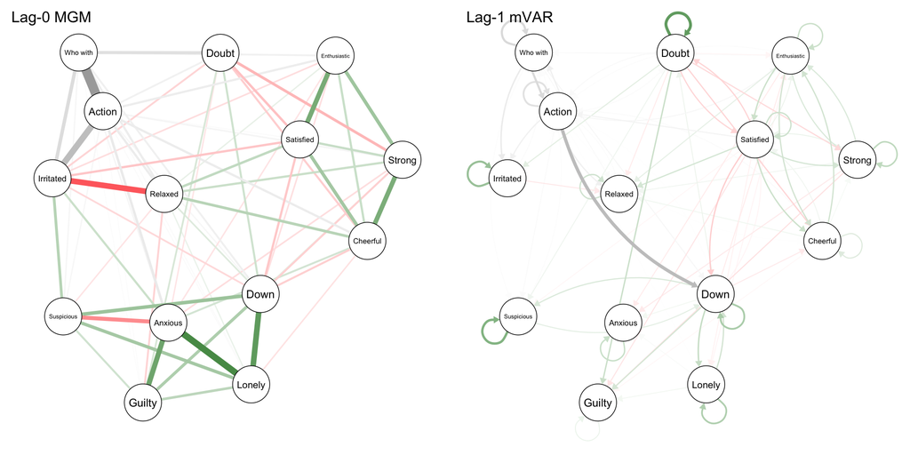

```r
# Get maximum parameter
max_par <- max(max(mgm_obj$pairwise$wadj), max(mvar_obj$wadj[, , 1]))

# Visualize
par(mfrow=c(1,2))
Q <- qgraph(mgm_obj$pairwise$wadj,
            layout = "spring",
            edge.color = mgm_obj$pairwise$edgecolor,
            labels = symptom_data_short$colnames,
            maximum = max_par,
            title = "Lag-0 MGM")

qgraph(t(mvar_obj$wadj[, , 1]),
       layout = Q$layout,
       edge.color = t(mvar_obj$edgecolor[, , 1]),
       labels = symptom_data_short$colnames,
       maximum = max_par,
       title = "Lag-1 mVAR")
```

The interactions are stronger in the MGM. The models show a quite different structure.